# Predicting Average Movie Rating

Caitlyn Vasquez

2024-03-23

# Introduction

The purpose of this project is to develop a model that will predict the average rating (of TMDb users) on a movie.

## Why?

As a movie enthusiast, I’ve enjoyed a lot of exceptional films, along with some lackluster ones. The idea of predicting the average vote of a film strikes me as a valuable tool to fine-tune my movie choices. By using machine learning to predict how audiences rate films collectively, I hope to discover more crowd-pleasing movies while avoiding the duds. I’m curious to explore the factors that influence these ratings without having to watch it myself.

There are multiple reasons why predicting overall rating for a movie can be useful:

### Recommendation System

Accurate predictions of movie ratings enable the creation of recommendation systems. By understanding users’ preferences and behaviors, platforms like TMDb, streaming services, or movie rental services can recommend personalized movie suggestions to users. This enhances user experience and engagement by offering relevant content tailored to individual tastes.

### Content Curation

Predicted ratings can assist content creators, producers, and distributors in understanding audience preferences. This allows them to create movies with similar content that aligns with audience expectations, leading to increased viewership and revenue.

### Market Analysis

Analyzing predicted movie ratings can serve as a tool for evaluating the potential success of upcoming movies. It provides valuable insights into trends and audience preferences, guiding marketing strategies for optimized performance in the film industry.

# Loading Packages and Raw Data

First, let’s load the necessary packages and raw data set.

```r
# Load necessary packages
library(tidyverse)
library(tidymodels)
library(janitor)
library(corrplot)
library(yardstick)
library(dplyr)
library(kknn)
library(parsnip)
library(tune)
library(glmnet)
library(caret)
library(vip)

# Import raw data
movie <- read.csv("~/pstat 131/project/archive/movies_metadata.csv")
head(movie)
```

|  | adult | belongs_to_collection | budget | genres | homepage | id | imdb_id | original_language | original_title | overview | popularity | poster_path | production_companies | production_countries | release_date | revenue | runtime | spoken_languages | status | tagline | title | video | vote_average | vote_count |
| --- | --- | --- | --- | --- | --- | --- | --- | --- | --- | --- | --- | --- | --- | --- | --- | --- | --- | --- | --- | --- | --- | --- | --- | --- |
| 1 | False | {'id': 10194, 'name': 'Toy Story Collection', 'poster_path': '/7G9915LfUQ2lVfwMEEhDsn3kT4B.jpg', 'backdrop_path': '/9FBwqcd9IRruEDUrTdcaafOMKUq.jpg'} | 30000000 | [{'id': 16, 'name': 'Animation'}, {'id': 35, 'name': 'Comedy'}, {'id': 10751, 'name': 'Family'}] | http://toystory.disney.com/toy-story | 862 | tt0114709 | en | Toy Story | Led by Woody, Andy's toys live happily in his room until Andy's birthday brings Buzz Lightyear onto the scene. Afraid of losing his place in Andy's heart, Woody plots against Buzz. But when circumstan… | 21.946943 | /rhIRbceoE9lR4veEXuwCC2wARtG.jpg | [{'name': 'Pixar Animation Studios', 'id': 3}] | [{'iso_3166_1': 'US', 'name': 'United States of America'}] | 1995-10-30 | 373554033 | 81 | [{'iso_639_1': 'en', 'name': 'English'}] | Released |  | Toy Story | False | 7.7 | 5415 |
| 2 | False |  | 65000000 | [{'id': 12, 'name': 'Adventure'}, {'id': 14, 'name': 'Fantasy'}, {'id': 10751, 'name': 'Family'}] |  | 8844 | tt0113497 | en | Jumanji | When siblings Judy and Peter discover an enchanted board game that opens the door to a magical world, they unwittingly invite Alan -- an adult who's been trapped inside the game for 26 years -- into t… | 17.015539 | /vzmL6fP7aPKNKPRTFnZmiUfciyV.jpg | [{'name': 'TriStar Pictures', 'id': 559}, {'name': 'Teitler Film', 'id': 2550}, {'name': 'Interscope Communications', 'id': 10201}] | [{'iso_3166_1': 'US', 'name': 'United States of America'}] | 1995-12-15 | 262797249 | 104 | [{'iso_639_1': 'en', 'name': 'English'}, {'iso_639_1': 'fr', 'name': 'Français'}] | Released | Roll the dice and unleash the excitement! | Jumanji | False | 6.9 | 2413 |
| 3 | False | {'id': 119050, 'name': 'Grumpy Old Men Collection', 'poster_path': '/nLvUdqgPgm3F85NMCii9gVFUcet.jpg', 'backdrop_path': '/hypTnLot2z8wpFS7qwsQHW1uV8u.jpg'} | 0 | [{'id': 10749, 'name': 'Romance'}, {'id': 35, 'name': 'Comedy'}] |  | 15602 | tt0113228 | en | Grumpier Old Men | A family wedding reignites the ancient feud between next-door neighbors and fishing buddies John and Max. Meanwhile, a sultry Italian divorcée opens a restaurant at the local bait shop, alarming the l… | 11.7129 | /6ksm1sjKMFLbO7UY2i6G1ju9SML.jpg | [{'name': 'Warner Bros.', 'id': 6194}, {'name': 'Lancaster Gate', 'id': 19464}] | [{'iso_3166_1': 'US', 'name': 'United States of America'}] | 1995-12-22 | 0 | 101 | [{'iso_639_1': 'en', 'name': 'English'}] | Released | Still Yelling. Still Fighting. Still Ready for Love. | Grumpier Old Men | False | 6.5 | 92 |
| 4 | False |  | 16000000 | [{'id': 35, 'name': 'Comedy'}, {'id': 18, 'name': 'Drama'}, {'id': 10749, 'name': 'Romance'}] |  | 31357 | tt0114885 | en | Waiting to Exhale | Cheated on, mistreated and stepped on, the women are holding their breath, waiting for the elusive "good man" to break a string of less-than-stellar lovers. Friends and confidants Vannah, Bernie, Glo … | 3.859495 | /16XOMpEaLWkrcPqSQqhTmeJuqQl.jpg | [{'name': 'Twentieth Century Fox Film Corporation', 'id': 306}] | [{'iso_3166_1': 'US', 'name': 'United States of America'}] | 1995-12-22 | 81452156 | 127 | [{'iso_639_1': 'en', 'name': 'English'}] | Released | Friends are the people who let you be yourself... and never let you forget it. | Waiting to Exhale | False | 6.1 | 34 |
| 5 | False | {'id': 96871, 'name': 'Father of the Bride Collection', 'poster_path': '/nts4iOmNnq7GNicycMJ9pSAn204.jpg', 'backdrop_path': '/7qwE57OVZmMJChBpLEbJEmzUydk.jpg'} | 0 | [{'id': 35, 'name': 'Comedy'}] |  | 11862 | tt0113041 | en | Father of the Bride Part II | Just when George Banks has recovered from his daughter's wedding, he receives the news that she's pregnant ... and that George's wife, Nina, is expecting too. He was planning on selling their home, bu… | 8.387519 | /e64sOI48hQXyru7naBFyssKFxVd.jpg | [{'name': 'Sandollar Productions', 'id': 5842}, {'name': 'Touchstone Pictures', 'id': 9195}] | [{'iso_3166_1': 'US', 'name': 'United States of America'}] | 1995-02-10 | 76578911 | 106 | [{'iso_639_1': 'en', 'name': 'English'}] | Released | Just When His World Is Back To Normal... He's In For The Surprise Of His Life! | Father of the Bride Part II | False | 5.7 | 173 |
| 6 | False |  | 60000000 | [{'id': 28, 'name': 'Action'}, {'id': 80, 'name': 'Crime'}, {'id': 18, 'name': 'Drama'}, {'id': 53, 'name': 'Thriller'}] |  | 949 | tt0113277 | en | Heat | Obsessive master thief, Neil McCauley leads a top-notch crew on various insane heists throughout Los Angeles while a mentally unstable detective, Vincent Hanna pursues him without rest. Each man recog… | 17.924927 | /zMyfPUelumio3tiDKPffaUpsQTD.jpg | [{'name': 'Regency Enterprises', 'id': 508}, {'name': 'Forward Pass', 'id': 675}, {'name': 'Warner Bros.', 'id': 6194}] | [{'iso_3166_1': 'US', 'name': 'United States of America'}] | 1995-12-15 | 187436818 | 170 | [{'iso_639_1': 'en', 'name': 'English'}, {'iso_639_1': 'es', 'name': 'Español'}] | Released | A Los Angeles Crime Saga | Heat | False | 7.7 | 1886 |

This data was taken from the Kaggle data set, “[The Movies Dataset](https://www.kaggle.com/datasets/rounakbanik/the-movies-dataset)” by user Rounak Banik. The dataset contains six files but we will only be using the movies_metadata.csv file. These files contain metadata for all 45,000 movies listed in the Full MovieLens Dataset and consists of movies released on or before July 2017.

# Exploring and Tidying Raw Data

## Variable Selection

To get a better understanding, let’s explore our data!

```r
dim(movie)
```

```
## [1] 45466    24
```

The dataset comprises 45,466 rows and 24 columns, which means we have 45,466 unique movies and 24 variables. Among these variables, `vote_average` serves as our response variable, but that still leaves us with 23 predictor variables. Let’s refine our selection!

There are a few repetitive variables in the data (i.e. keep `original_title` and omit `title`, etc.) and some variables that are not as relevant when determining average vote/TMDb user ratings (i.e. `homepage`, `poster_path`, etc.). So we will omit these columns and keep the columns of relevant variables (as described under **Codebook**).

```r
# Keeping selected variables
movie <- movie %>%
  select(c('budget', 'genres', 'id', 'original_title', 'popularity', 'production_companies', 'release_date', 'revenue', 'runtime', 'vote_average', 'vote_count'))

head(movie)
```

|  | budget | genres | id | original_title | popularity | production_companies | release_date | revenue | runtime | vote_average | vote_count |
| --- | --- | --- | --- | --- | --- | --- | --- | --- | --- | --- | --- |
| 1 | 30000000 | [{'id': 16, 'name': 'Animation'}, {'id': 35, 'name': 'Comedy'}, {'id': 10751, 'name': 'Family'}] | 862 | Toy Story | 21.946943 | [{'name': 'Pixar Animation Studios', 'id': 3}] | 1995-10-30 | 373554033 | 81 | 7.7 | 5415 |
| 2 | 65000000 | [{'id': 12, 'name': 'Adventure'}, {'id': 14, 'name': 'Fantasy'}, {'id': 10751, 'name': 'Family'}] | 8844 | Jumanji | 17.015539 | [{'name': 'TriStar Pictures', 'id': 559}, {'name': 'Teitler Film', 'id': 2550}, {'name': 'Interscope Communications', 'id': 10201}] | 1995-12-15 | 262797249 | 104 | 6.9 | 2413 |
| 3 | 0 | [{'id': 10749, 'name': 'Romance'}, {'id': 35, 'name': 'Comedy'}] | 15602 | Grumpier Old Men | 11.7129 | [{'name': 'Warner Bros.', 'id': 6194}, {'name': 'Lancaster Gate', 'id': 19464}] | 1995-12-22 | 0 | 101 | 6.5 | 92 |
| 4 | 16000000 | [{'id': 35, 'name': 'Comedy'}, {'id': 18, 'name': 'Drama'}, {'id': 10749, 'name': 'Romance'}] | 31357 | Waiting to Exhale | 3.859495 | [{'name': 'Twentieth Century Fox Film Corporation', 'id': 306}] | 1995-12-22 | 81452156 | 127 | 6.1 | 34 |
| 5 | 0 | [{'id': 35, 'name': 'Comedy'}] | 11862 | Father of the Bride Part II | 8.387519 | [{'name': 'Sandollar Productions', 'id': 5842}, {'name': 'Touchstone Pictures', 'id': 9195}] | 1995-02-10 | 76578911 | 106 | 5.7 | 173 |
| 6 | 60000000 | [{'id': 28, 'name': 'Action'}, {'id': 80, 'name': 'Crime'}, {'id': 18, 'name': 'Drama'}, {'id': 53, 'name': 'Thriller'}] | 949 | Heat | 17.924927 | [{'name': 'Regency Enterprises', 'id': 508}, {'name': 'Forward Pass', 'id': 675}, {'name': 'Warner Bros.', 'id': 6194}] | 1995-12-15 | 187436818 | 170 | 7.7 | 1886 |

## Tidying Variables

The `genres` variable appears as a list since some movies have more than one genre. For simplification purposes, we are going to create a new variable `genre` with the first listed genre from `genres`. The `production_companies` variable also appears as a list so we will do the same to that variable.

```r
movie['genre'] = gsub("\\[\\{'id':\\s*\\d+,\\s*'name':\\s*'([^']*)'.*", "\\1", movie$genres)

movie['production_company'] = gsub("\\[\\{'name':\\s*'([^']*)'.*", "\\1", movie$production_companies)

movie <- movie %>%
  select(-c('genres', 'production_companies'))
```

For further simplification purposes when exploring the data, let’s create a new variable `release_year` and extract the year from the `release_date` variable accordingly.

```r
movie['release_year'] <- substr(movie$release_date, 1, 4)

movie <- movie %>%
  select(-c('release_date'))

# Tidied data
head(movie)
```

|  | budget | id | original_title | popularity | revenue | runtime | vote_average | vote_count | genre | production_company | release_year |
| --- | --- | --- | --- | --- | --- | --- | --- | --- | --- | --- | --- |
| 1 | 30000000 | 862 | Toy Story | 21.946943 | 373554033 | 81 | 7.7 | 5415 | Animation | Pixar Animation Studios | 1995 |
| 2 | 65000000 | 8844 | Jumanji | 17.015539 | 262797249 | 104 | 6.9 | 2413 | Adventure | TriStar Pictures | 1995 |
| 3 | 0 | 15602 | Grumpier Old Men | 11.7129 | 0 | 101 | 6.5 | 92 | Romance | Warner Bros. | 1995 |
| 4 | 16000000 | 31357 | Waiting to Exhale | 3.859495 | 81452156 | 127 | 6.1 | 34 | Comedy | Twentieth Century Fox Film Corporation | 1995 |
| 5 | 0 | 11862 | Father of the Bride Part II | 8.387519 | 76578911 | 106 | 5.7 | 173 | Comedy | Sandollar Productions | 1995 |
| 6 | 60000000 | 949 | Heat | 17.924927 | 187436818 | 170 | 7.7 | 1886 | Action | Regency Enterprises | 1995 |

Now, let’s check for any missing data.

```r
sum(is.na(movie))
```

```
## [1] 281
```

It appears that we have 281 missing data. Let’s omit those.

```r
movie <- na.omit(movie)
```

Let’s double check to make sure they were successfully removed.

```r
sum(is.na(movie))
```

```
## [1] 0
```

We no longer have any missing data, however, we have a good amount of data where the attributing values do not make sense. For instance, some of the values from `genres` and `production_companies` were empty strings to begin with (i.e. the corresponding value is ‘[]’).

One significant challenge posed by this dataset is the presence of zero values in certain variables where such values are logically implausible. The decision to eliminate these rows results in a reduction from approximately 45,000 observations to around 5,000, which unfortunately means we are omitting a lot of movies. Imputing the data for those zero values is not advisable, so we will remove those rows. Luckily, the remaining 5,000 observations still constitute a sizable dataset.

```r
# Remove any movies and production companies with no data (i.e. the corresponding value is '[]') as well as any rows where the runtime, revenue, and budget is 0.
no_genre <- sum(movie$genre == "[]")
no_prod_comp <- sum(movie$production_company == "[]")
no_runtime <- sum(movie$runtime == 0)
no_revenue <- sum(movie$revenue == 0)
no_budget <- sum(movie$budget == 0)

print(paste("Number of movies with missing genre(s):", no_genre))
```

```
## [1] "Number of movies with missing genre(s): 2364"
```

```r
print(paste("Number of movies with missing production company(s):", no_prod_comp))
```

```
## [1] "Number of movies with missing production company(s): 11709"
```

```r
print(paste("Number of movies with runtime of 0:", no_runtime))
```

```
## [1] "Number of movies with runtime of 0: 1558"
```

```r
print(paste("Number of movies with revenue of 0:", no_revenue))
```

```
## [1] "Number of movies with revenue of 0: 37801"
```

```r
print(paste("Number of movies with budget of 0:", no_budget))
```

```
## [1] "Number of movies with budget of 0: 36323"
```

```r
movie <- subset(movie, genre != "[]")
movie <- subset(movie, production_company != "[]" )
movie <- subset(movie, runtime != 0)
movie <- subset(movie, revenue != 0)
movie <- subset(movie, budget != 0)
dim(movie)
```

```
## [1] 5193   11
```

Now that we have removed those rows, do we notice anything else? Well, a lot of the variables are of character type, including the ones where numeric type would be more appropriate (e.g. `budget` and `popularity`). Let’s also change any categorical variables to factors.

```r
# Convert character variables to numeric type accordingly.
movie <- movie %>%
  dplyr::mutate(budget = as.numeric(budget),
         popularity = as.numeric(popularity),
         release_year = as.numeric(release_year))

head(movie)
```

|  | budget | id | original_title | popularity | revenue | runtime | vote_average | vote_count | genre | production_company | release_year |
| --- | --- | --- | --- | --- | --- | --- | --- | --- | --- | --- | --- |
| 1 | 3.0e+07 | 862 | Toy Story | 21.946943 | 373554033 | 81 | 7.7 | 5415 | Animation | Pixar Animation Studios | 1995 |
| 2 | 6.5e+07 | 8844 | Jumanji | 17.015539 | 262797249 | 104 | 6.9 | 2413 | Adventure | TriStar Pictures | 1995 |
| 4 | 1.6e+07 | 31357 | Waiting to Exhale | 3.859495 | 81452156 | 127 | 6.1 | 34 | Comedy | Twentieth Century Fox Film Corporation | 1995 |
| 6 | 6.0e+07 | 949 | Heat | 17.924927 | 187436818 | 170 | 7.7 | 1886 | Action | Regency Enterprises | 1995 |
| 9 | 3.5e+07 | 9091 | Sudden Death | 5.231580 | 64350171 | 106 | 5.5 | 174 | Action | Universal Pictures | 1995 |
| 10 | 5.8e+07 | 710 | GoldenEye | 14.686036 | 352194034 | 130 | 6.6 | 1194 | Adventure | United Artists | 1995 |

```r
# Converting categorical variables to factors.
movie <- movie %>%
  dplyr::mutate(genre = factor(genre),
         production_company = factor(production_company))
```

Let’s take a quick look at the summary statistics of each variable!

```r
movie %>%
  summary()
```

```
##      budget               id            original_title       popularity
##  Min.   :        1   Length:5193        Length:5193        Min.   :  0.0306
##  1st Qu.:  6000000   Class :character   Class :character   1st Qu.:  5.7950
##  Median : 18000000   Mode  :character   Mode  :character   Median :  8.5816
##  Mean   : 32076943                                         Mean   : 10.0535
##  3rd Qu.: 40000000                                         3rd Qu.: 11.8451
##  Max.   :380000000                                         Max.   :547.4883
##
##     revenue             runtime       vote_average     vote_count
##  Min.   :1.000e+00   Min.   : 26.0   Min.   :0.000   Min.   :    0.0
##  1st Qu.:8.179e+06   1st Qu.: 96.0   1st Qu.:5.800   1st Qu.:   90.0
##  Median :3.217e+07   Median :106.0   Median :6.300   Median :  294.0
##  Mean   :9.339e+07   Mean   :110.2   Mean   :6.291   Mean   :  757.9
##  3rd Qu.:1.028e+08   3rd Qu.:120.0   3rd Qu.:6.900   3rd Qu.:  844.0
##  Max.   :2.788e+09   Max.   :338.0   Max.   :9.100   Max.   :14075.0
##
##        genre                                   production_company
##  Drama    :1260   Paramount Pictures                    : 336
##  Comedy   :1024   Universal Pictures                    : 329
##  Action   : 933   Twentieth Century Fox Film Corporation: 247
##  Adventure: 409   Columbia Pictures                     : 209
##  Horror   : 320   New Line Cinema                       : 164
##  Crime    : 261   Walt Disney Pictures                  : 131
##  (Other)  : 986   (Other)                               :3777
##   release_year
##  Min.   :1915
##  1st Qu.:1994
##  Median :2004
##  Mean   :2000
##  3rd Qu.:2011
##  Max.   :2017
##
```

For each numeric variable, the summary statistics provide the minimum, median, maximum, first quantile, third quantile, and mean value. For character values like `genre` and `production_company`, it provides the count of the most frequent categories and lumps the rest into ‘(Other)’. For character values like `id` and `original_title` where the observations are unique, it displays the sum of observations. We see that our outcome variable `vote_average` ranges from 0 to 9.1 in our dataset.

For further information about our variables, explore the **Codebook** below!

## Codebook

- budget (dbl): total budget of movie in USD
- id (chr): unique identifier for each movie on TMDb
- original_title (chr): title of movie in its original language
- popularity (dbl): “lifetime” metric from TMDd to measure popularity of movie and is impacted by the following: number of votes for the day, number of views for the day, number of users who marked it as a “favorite” for the day, number of users who added it to their “watchlist” for the day, release date, number of total votes, previous days score
- revenue (dbl): total revenue of movie in USD
- runtime (dbl): duration of the movie in minutes
- vote_average (dbl): average of all TMBd user ratings for a movie (0-10)
- vote_count (dbl): number of voters of movie
- genre (chr): primary genre of movie
- production_company (chr): production company of movie
- release_year (dbl): year of movie release

# Exploratory Data Analysis (EDA)

Let’s explore our data!

## Vote Average

First, we’ll take a look at the distribution of our response variable, `vote_average`.

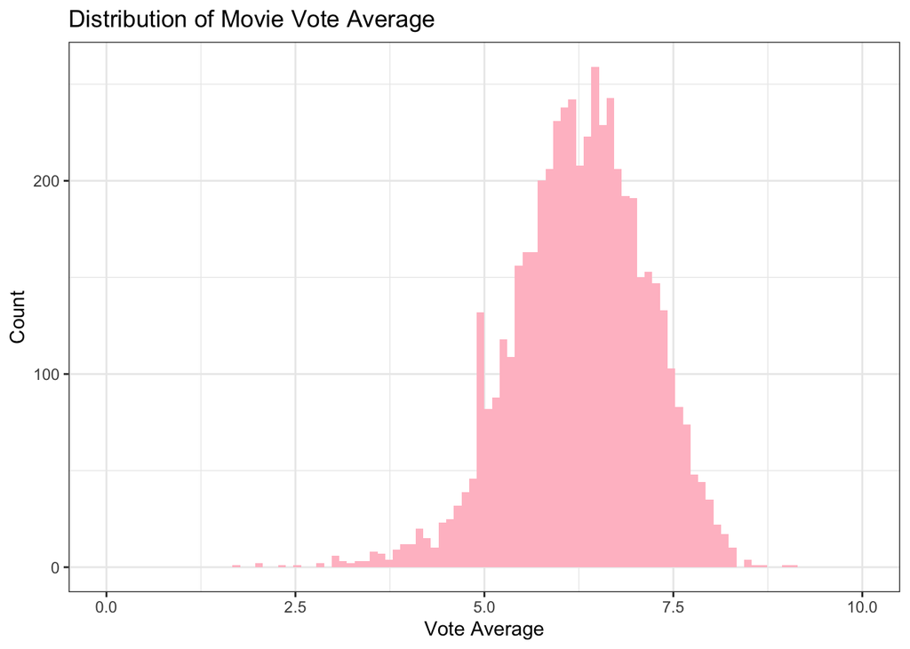

```r
ggplot(data=movie, aes(x=vote_average)) +
  geom_histogram(bins=100, fill="pink") +
  theme_bw() +
  ggtitle("Distribution of Movie Vote Average") +
  xlim(0,10) +
  labs (x="Vote Average", y="Count")
```

The distribution of `vote_average` is symmetric with a peak around 6.3. This means the most common average TMBd user rating from our dataset is approximately 6.3/10. From the plot, the ratings range from ~1.5 to ~9, which makes sense since ratings are on a 0-10 scale.

## Genre

The data contains movies from a wide variety of genres. Let’s see how many movies are in each genre category.

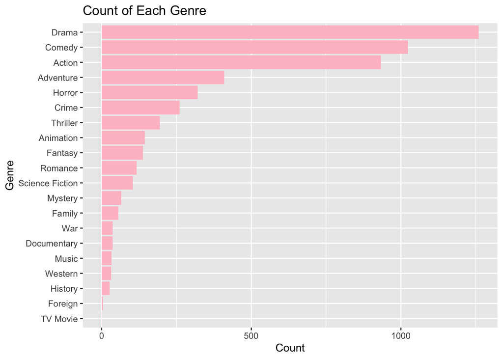

```r
movie %>%
  count(genre) %>%
  arrange(desc(n)) %>%
  ggplot(aes(y = reorder(genre, n), x = n)) +
  geom_bar(stat = "identity", fill = "pink") +
  labs(
    title = "Count of Each Genre",
    x = "Count",
    y = "Genre"
  )
```

‘Drama’ appears to be the most frequent genre, with over 1250 movies in that category, followed by ‘Comedy,’ ‘Action,’ ‘Adventure,’ ‘Horror,’ and ‘Crime.’ The remaining 14 genres each have under 250 movies in their respective categories.

Since we have 20 genres, let’s narrow that down! We’ll leave the top five genres and lump the remaining genres into an ‘other_genres’ category.

```r
movie <- movie %>%
  filter(!is.na(genre)) %>%
  mutate(genre = fct_lump(genre, n = 5, other_level = "other_genres"))
```

## Production Company

Production company can play a significant role in determining the average rating of a movie. Certain companies may have a reputation of producing high-quality films or may have larger budgets to afford better resources. These attributes have the potential to influence the rating of a film. Let’s take a look at the most common production companies in our data set.

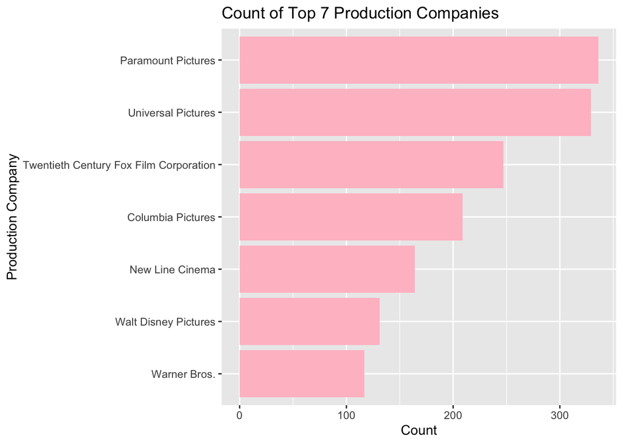

```r
# Count the frequency of each production company
company_frequency <- table(movie$production_company)

# Sort the frequencies in descending order
sorted_frequency <- sort(company_frequency, decreasing = TRUE)

# Extract the top 7 production companies and their frequencies
top_7 <- head(sorted_frequency, 7)

# Convert 'top_7' to a data frame for ggplot
top_7_df <- data.frame(production_company = names(top_7), frequency = as.numeric(top_7))

# Create a horizontal bar plot
ggplot(top_7_df, aes(x = frequency, y = reorder(production_company, frequency))) +
  geom_bar(stat = "identity", fill = "pink") +
  labs(
    title = "Count of Top 7 Production Companies",
    x = "Count",
    y = "Production Company"
  )
```

Looking at the bar plot of the top 7 most common production companies, we see that Paramount Pictures has produced the most number of movies (over 300), followed closely by Universal Pictures. If we add up the counts, these 7 production companies produce almost a third of the movies in the dataset.

We will simplify our `production_company` variable, so, we will use the top two production companies and lump the rest into an ‘other_companies’ category.

```r
# Lump the production companies together that are not in the top 2
movie <- movie %>%
  filter(!is.na(production_company)) %>%
  mutate(production_company = fct_lump(production_company, n = 2, other_level = "other_companies"))
```

Let’s take a look at the overall spread between `production_company` and `vote_average`!

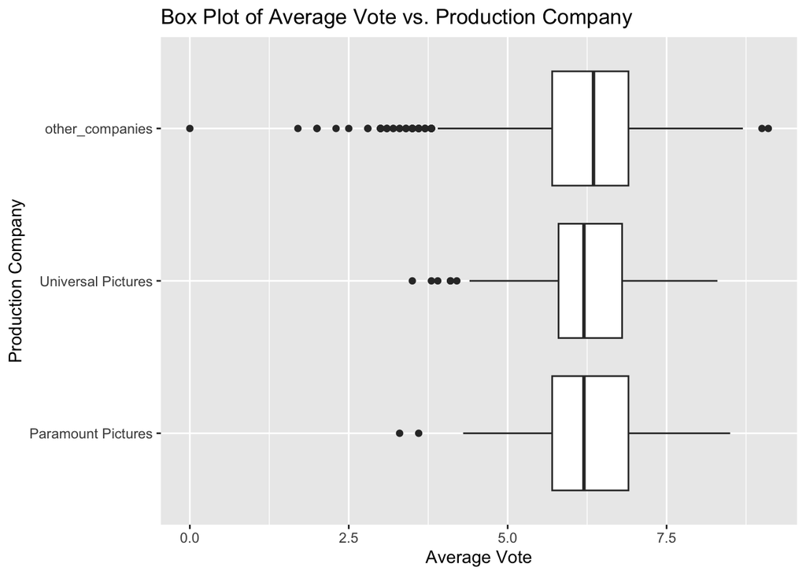

```r
movie %>%
  ggplot(aes(x = vote_average, y = production_company)) + geom_boxplot() +
  labs(title = "Box Plot of Average Vote vs. Production Company",
       x = "Average Vote", y = "Production Company")
```

From this box plot, we observe that the interquartile (IQ) range for Universal Pictures is the smallest while Paramount Pictures and the other companies have a very similar IQ range. Although all the IQ ranges are between 5.0 and 7.5. The whiskers are shortest for Universal Pictures, followed by Paramount Pictures and then the other companies. But, they are still very close in length, indicating that there isn’t a significant difference in average votes across production companies. We see that ‘Universal Pictures’ and ‘Paramount Pictures’ have a slightly lower median vote than the other companies but only by a few tenths.

## Release Year

Let’s take a look at the distribution of the `release_year` variable!

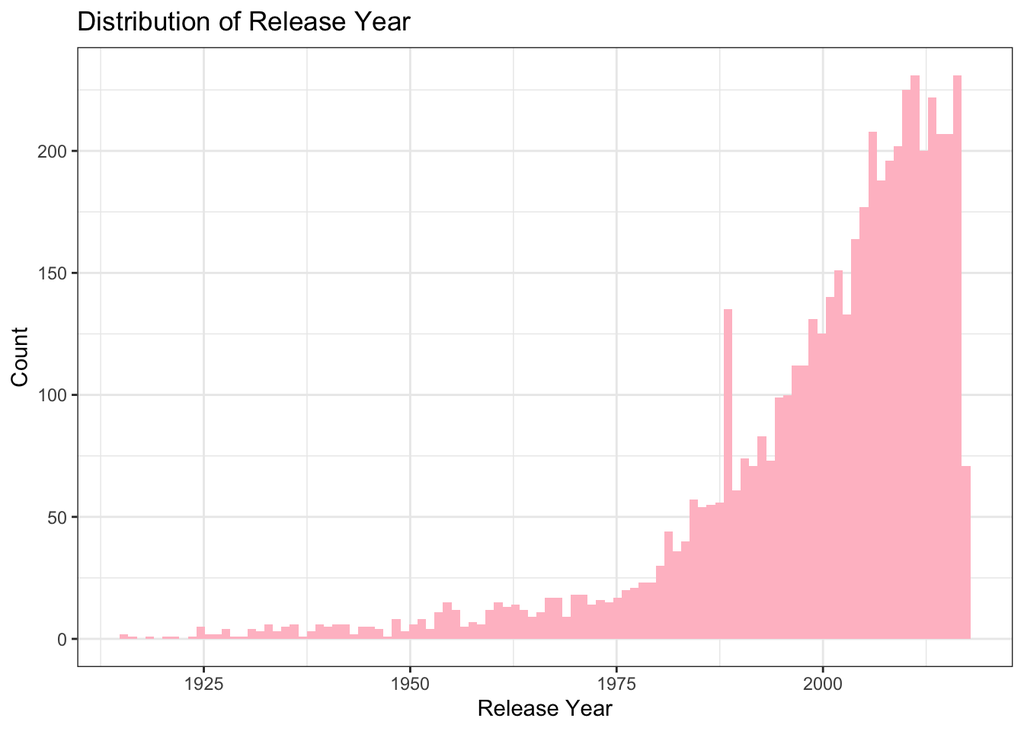

```r
ggplot(data=movie, aes(x=release_year)) +
  geom_histogram(bins=100, fill="pink") +
  theme_bw() +
  ggtitle("Distribution of Release Year") +
  labs (x="Release Year", y="Count")
```

We observe that the `release_year` variable is left-skewed, meaning that a majority of the movies in this dataset have been released more recently (2000-2017).

## Runtime

We’ll also take a look at the distribution of runtime!

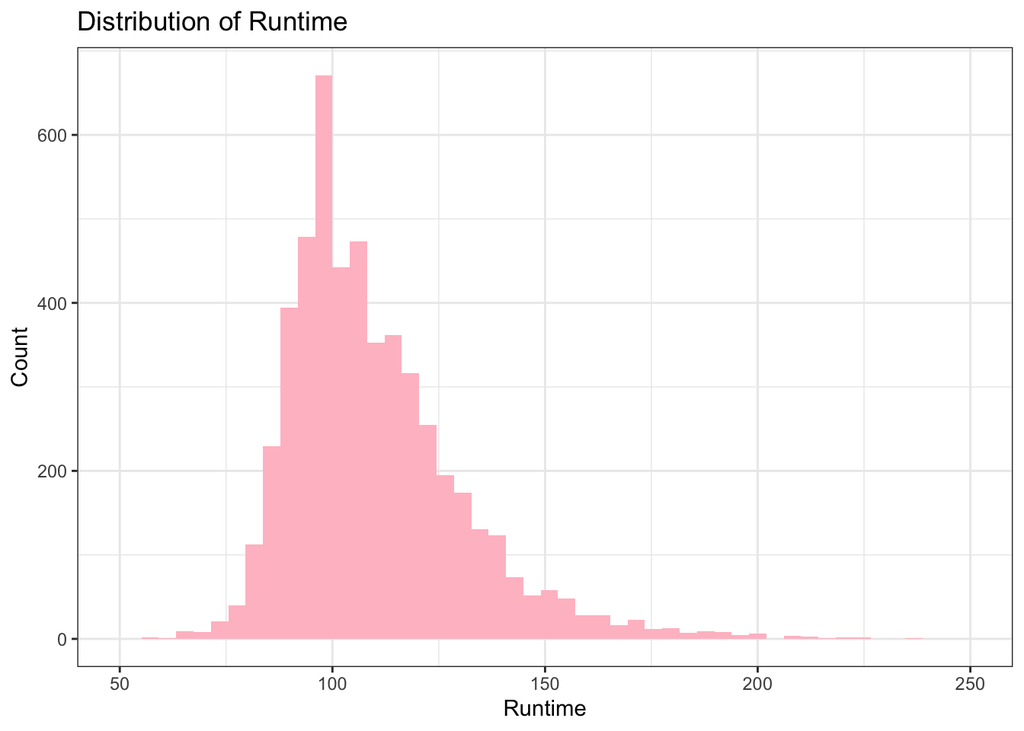

```r
ggplot(data=movie, aes(x=runtime)) +
  geom_histogram(bins=50, fill="pink") +
  theme_bw() +
  ggtitle("Distribution of Runtime") +
  labs (x="Runtime", y="Count") +
  xlim(50,250)
```

The variable `runtime` is roughly symmetric, perhaps with a slight right-skew, with a peak at around 100 which tells us that the average runtime of the movies in our dataset is approximately 100 minutes.

## Correlation Plot

Now, let’s explore the overall relationships between all of the continuous predictor variables using a correlation plot!

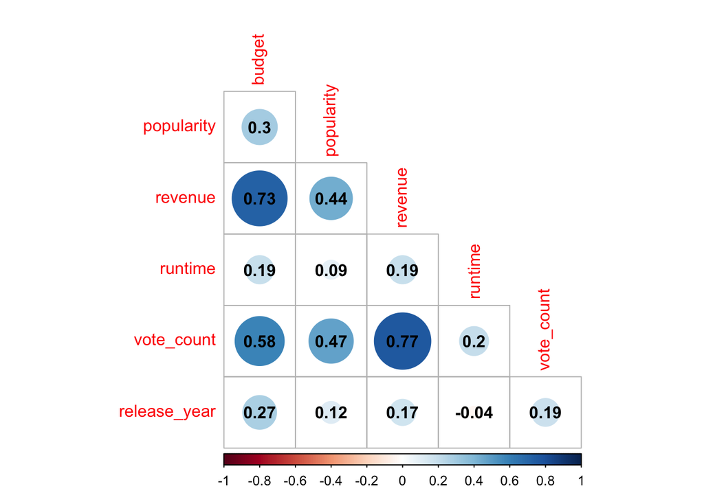

```r
movie %>%
  select(is.numeric) %>%
  select(-vote_average) %>%
  cor(use = "pairwise.complete.obs") %>%
  corrplot(type = "lower", diag = FALSE, addCoef.col = 1)
```

One relationship that stands out is the strong, positive correlation between `vote_count` and `revenue` with a correlation value of 0.77. Another notable relationship is a strong, positive correlation between `revenue` and `budget` with a correlation value of 0.73. There are also moderately positive correlations between `budget` and `vote_count`, `popularity` and `vote_count`, and `popularity` and `revenue`.

## Vote Count and Revenue

Since we previously discussed the relationship between `vote_count` and `revenue`, let’s take a closer look at the correlation between the two.

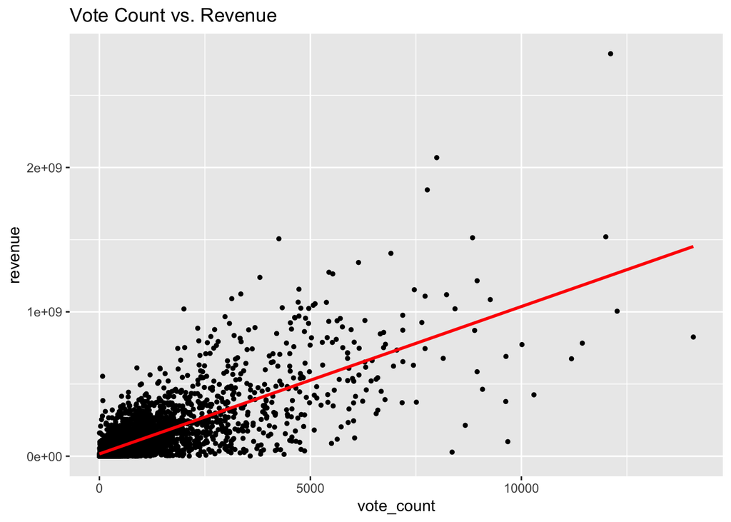

```r
movie %>%
  ggplot(aes(x=vote_count, y=revenue)) +
  geom_jitter(width = 0.5, size = 1) +
  geom_smooth(method = "lm", se =F, col="red") +
  labs(title = "Vote Count vs. Revenue")
```

As mentioned in our correlation plot and as observed in the above graph, `vote_count` and `revenue` have a highly positive correlation. This logically makes sense because as revenue increases, it indicates a higher number of viewers which usually results in more people voting for the movie.

Let’s also take a closer look at the correlation between `budget` and `revenue`!

## Budget and Revenue

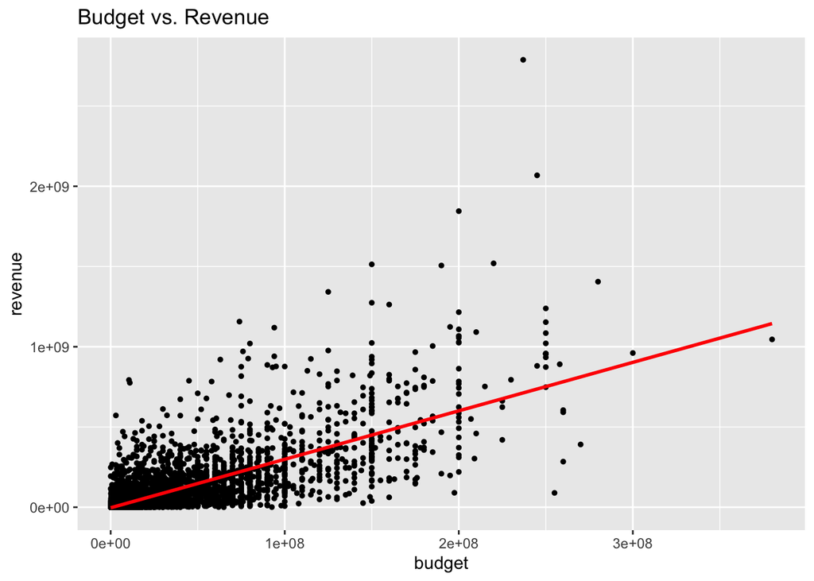

```r
movie %>%
  ggplot(aes(x=budget, y=revenue)) +
  geom_jitter(width = 0.5, size = 1) +
  geom_smooth(method = "lm", se =F, col="red") +
  labs(title = "Budget vs. Revenue")
```

The graph depicts that as budget increases, revenue increases as well. It shows a positive relationship which is reasonable because movies with higher budgets have access to better production values (e.g. higher-quality special effects, talented actors, extensive marketing campaigns, etc.) thus attracting larger audiences and generating higher revenue.

# Model Preparation

Before we build and fit our models, we must prepare them first. We need to split the data, create the recipe, and create folds for *k*-fold cross validation.

## Splitting the Data

First, let’s split the data into two sets: training and testing. The training set is a portion of the data set that is used to teach the model patterns and relationships, hence “training.” The testing set is a separate portion reserved for evaluating the model’s performance on unseen data. I have chosen to split my data so that 70% goes towards training and 30% goes towards testing.

```r
set.seed(123)
movie_split <- initial_split(movie, strata = "vote_average", prop = 0.7)

movie_train <- training(movie_split)
movie_test <- testing(movie_split)
```

Let’s take a look at the dimensions of our dataset as well as the training and testing sets to ensure we have a 70/30 split.

```r
dim(movie)
```

```
## [1] 5193   11
```

```r
dim(movie_train)
```

```
## [1] 3633   11
```

```r
dim(movie_test)
```

```
## [1] 1560   11
```

Great! Let’s move on to the next step of our model preparation.

## Creating the Recipe

We will create a universal recipe for all of our models to use. This recipe will consist of the predictor variables we explored in the EDA step. The 8 predictors are: `budget`, `popularity`, `revenue`, `runtime`, `vote_count`, `genre`, `production_company`, and `release_year`.

Since `genre` and `production_company` are categorical variables, we’ll make them dummy variables.

Lastly, we’ll normalize our variables.

```r
movie_recipe <- recipe(vote_average ~ budget + popularity + revenue + runtime + vote_count + genre + production_company + release_year, data = movie_train) %>%
  step_dummy(genre) %>%
  step_dummy(production_company) %>%
  step_nzv(all_predictors()) %>%
  step_normalize(all_predictors())

movie_recipe %>% prep() %>% bake(new_data=movie_train)
```

| budget | popularity | revenue | runtime | vote_count | release_year | vote_average | genre_Adventure | genre_Comedy | genre_Drama | genre_Horror | genre_other_genres | production_company_Universal.Pictures | production_company_other_companies |
| --- | --- | --- | --- | --- | --- | --- | --- | --- | --- | --- | --- | --- | --- |
| 0.075312329 | -0.4575978755 | -1.699931e-01 | -0.20738445 | -0.4599187365 | -0.28715452 | 5.5 | -0.2922775 | -0.4901927 | -0.5708088 | -0.2593362 | -0.5593641 | 3.7263281 | -2.5938263 |
| 1.618515098 | -0.2466626580 | -4.995634e-01 | 0.38795716 | -0.4891806820 | -0.28715452 | 5.7 | -0.2922775 | -0.4901927 | -0.5708088 | -0.2593362 | -0.5593641 | -0.2682868 | 0.3854247 |
| -0.341107466 | 0.1217640985 | 1.808856e-01 | -0.43636199 | -0.2400587134 | -0.28715452 | 5.4 | -0.2922775 | -0.4901927 | -0.5708088 | -0.2593362 | -0.5593641 | -0.2682868 | 0.3854247 |
| 0.442741560 | -0.3876617904 | -4.903607e-01 | -0.89431708 | -0.5548223436 | -0.28715452 | 4.1 | -0.2922775 | -0.4901927 | -0.5708088 | -0.2593362 | -0.5593641 | -0.2682868 | 0.3854247 |
| -0.414593312 | -0.6934232591 | -5.479367e-01 | -0.94011259 | -0.5848751526 | -0.22507214 | 3.9 | -0.2922775 | 2.0394524 | -0.5708088 | -0.2593362 | -0.5593641 | -0.2682868 | 0.3854247 |
| 0.369255714 | 0.3268532507 | -4.852356e-01 | -0.29897547 | -0.5366324856 | -0.22507214 | 5.7 | -0.2922775 | -0.4901927 | 1.7514179 | -0.2593362 | -0.5593641 | -0.2682868 | 0.3854247 |
| -0.439088594 | -0.0630843263 | -4.402240e-01 | -0.48215750 | -0.5081614035 | -0.28715452 | 4.5 | -0.2922775 | 2.0394524 | -0.5708088 | -0.2593362 | -0.5593641 | -0.2682868 | -2.5938263 |
| 0.442741560 | 0.5417535917 | 3.511773e-01 | -0.11579343 | -0.2345226696 | -0.22507214 | 5.7 | -0.2922775 | -0.4901927 | -0.5708088 | -0.2593362 | -0.5593641 | -0.2682868 | 0.3854247 |
| -0.169640491 | -0.8387149794 | -5.222444e-01 | 0.11318411 | -0.5919929231 | -0.28715452 | 5.1 | -0.2922775 | 2.0394524 | -0.5708088 | -0.2593362 | -0.5593641 | -0.2682868 | 0.3854247 |
| 0.197788739 | -0.3265501857 | -1.351160e-01 | 0.29636614 | -0.4875989553 | -0.47340167 | 5.4 | -0.2922775 | 2.0394524 | -0.5708088 | -0.2593362 | -0.5593641 | -0.2682868 | -2.5938263 |

[output cut: 3623 more lines]

## *K*-fold Cross Validation

We will create 5 folds for *k*-fold cross validation. This means that the dataset is divided into *k* subsets of approximately equal size (hence 5 folds). The model is trained *k* times, each time using *k*-1 folds for training and the remaining fold for validation. After each training-validation iteration, the performance of the model is evaluated using a metric, in this case RMSE, on the validation set. This results in *k* performance estimates. The *k* performance estimates are averaged to a single performance metric that represents the overall performance of the model.

By using *k*-fold cross validation, we can get a more reliable estimate of the model’s performance compared to a single train-test split. It helps mitigate the bias and variance that can arise from a single train-test split and provides a better assessment of how the model will perform on unseen data.

```r
movie_folds <- vfold_cv(movie_train, v = 5, strata = "vote_average")
```

# Building and Fitting/Tuning the Models

Let’s move on to constructing our models! We will be building five models: linear regression, *k*-nearest neighbors, elastic net, pruned decision trees, and random forest. I have chosen Root Mean Squared Error (RMSE) to evaluate the performance of these models. RMSE measures the average difference between a model’s predicted values and the actual values. So, a smaller RMSE means less average difference between the predicted and actual values which is better.

There are multiple steps we must take to fit these models, so let’s get started!

## Model Setup

For each model we’ll specify the model we want to fit, the parameters we want to tune, the engine the model comes from, and the mode, which in this case is regression.

```r
# Linear Regression
lm_model <- linear_reg() %>%
  set_engine("lm")

# K-Nearest Neighbors
knn_model <- nearest_neighbor(neighbors = tune()) %>%
  set_engine("kknn") %>%
  set_mode("regression")

# Elastic Net
en_model <- linear_reg(mixture = tune(),
                       penalty = tune()) %>%
  set_engine("glmnet") %>%
  set_mode("regression")

# Pruned Decision Trees
pd_model <- decision_tree(cost_complexity = tune()) %>%
  set_engine("rpart") %>%
  set_mode("regression")

# Random Forest
rf_model <- rand_forest(mtry = tune(),
                        trees = tune(),
                        min_n = tune()) %>%
  set_engine("ranger", importance = "impurity") %>%
  set_mode("regression")
```

## Workflow

Next, we’ll set up the workflows for each model by adding the respective model and the recipe.

```r
# Linear Regression
lm_workflow <- workflow() %>%
  add_model(lm_model) %>%
  add_recipe(movie_recipe)

# K-Nearest Neighbors
knn_workflow <- workflow() %>%
  add_model(knn_model) %>%
  add_recipe(movie_recipe)

# Elastic Net
en_workflow <- workflow() %>%
  add_model(en_model) %>%
  add_recipe(movie_recipe)

# Pruned Decision Trees
pd_workflow <- workflow() %>%
  add_model(pd_model) %>%
  add_recipe(movie_recipe)

# Random Forest
rf_workflow <- workflow() %>%
  add_model(rf_model) %>%
  add_recipe(movie_recipe)
```

## Creating Grids

Then, we’ll create tuning grids to specify the ranges for the tuning parameters and the number of levels.

```r
# Linear Regression
# No grid because no tuning parameters

# K-Nearest Neighbors
knn_grid <- grid_regular(neighbors(range = c(1, 30)), levels = 5)

# Elastic Net
en_grid <- grid_regular(penalty(),
                        mixture(range = c(0,1)),
                        levels = 10)

# Pruned Decision Trees
pd_grid <- grid_regular(cost_complexity(range = c(-3, -1)), levels = 10)

# Random Forest
rf_grid <- grid_regular(mtry(range = c(1, 6)),
                        trees(range = c(100, 1000)),
                        min_n(range = c(5, 20)),
                        levels = 8)
```

## Tuning

Now, we’ll tune the models by specifying the workflow, the *k*-fold cross validation, and the tuning grid.

```r
# Linear Regression
# No tuning

# K-Nearest Neighbors
knn_tune <- tune_grid(
  object = knn_workflow,
  resamples = movie_folds,
  grid = knn_grid
)

# Elastic Net
en_tune <- tune_grid(
  object = en_workflow,
  resamples = movie_folds,
  grid = en_grid
)

# Pruned Decision Trees
pd_tune <- tune_grid(
  object = pd_workflow,
  resamples = movie_folds,
  grid = pd_grid
)

# Random Forest
rf_tune <- tune_grid(
  object = rf_workflow,
  resamples = movie_folds,
  grid = rf_grid
)
```

## Save Tuned Models

Let’s save the tuned models to an RDA file to avoid rerunning the model…

```r
# Linear Regression
# No tuning

# K-Nearest Neighbors
save(knn_tune, file = "~/pstat 131/FINAL PROJECT/knn_tune.rda")

# Elastic Net
save(en_tune, file = "~/pstat 131/FINAL PROJECT/en_tune.rda")

# Pruned Decision Trees
save(pd_tune, file = "~/pstat 131/FINAL PROJECT/pd_tune.rda")

# Random Forest
save(rf_tune, file = "~/pstat 131/FINAL PROJECT/rf_tune.rda")
```

## Load Models In

…and then load the saved models in.

```r
# Linear Regression
# No tuning

# K-Nearest Neighbors
load("~/pstat 131/FINAL PROJECT/knn_tune.rda")

# Elastic Net
load("~/pstat 131/FINAL PROJECT/en_tune.rda")

# Pruned Decision Trees
load("~/pstat 131/FINAL PROJECT/pd_tune.rda")

# Random Forest
load("~/pstat 131/FINAL PROJECT/rf_tune.rda")
```

## Collect Metrics

Finally, we’ll collect the metrics and extract the lowest RMSE value from each model.

```r
# Linear Regression
lm_fit <- fit_resamples(lm_workflow, resamples = movie_folds)
lm_rmse <- collect_metrics(lm_fit) %>%
  dplyr::slice(1)
lm_rmse
```

| .metric | .estimator | mean | n | std_err | .config |
| --- | --- | --- | --- | --- | --- |
| rmse | standard | 0.7381683 | 5 | 0.01041129 | Preprocessor1_Model1 |

```r
# K-Nearest Neighbors
knn_rmse <- show_best(knn_tune, metric = "rmse", n = 1)
knn_rmse
```

| neighbors | .metric | .estimator | mean | n | std_err | .config |
| --- | --- | --- | --- | --- | --- | --- |
| 22 | rmse | standard | 0.7229949 | 5 | 0.0116511 | Preprocessor1_Model4 |

```r
# Elastic Net
en_rmse <- show_best(en_tune, metric = "rmse", n = 1)
en_rmse
```

| penalty | mixture | .metric | .estimator | mean | n | std_err | .config |
| --- | --- | --- | --- | --- | --- | --- | --- |
| 1e-10 | 0.6666667 | rmse | standard | 0.7722175 | 1 | NA | Preprocessor1_Model061 |

```r
# Pruned Decision Trees
pd_rmse <- show_best(pd_tune, metric = "rmse", n = 1)
pd_rmse
```

| cost_complexity | .metric | .estimator | mean | n | std_err | .config |
| --- | --- | --- | --- | --- | --- | --- |
| 0.002782559 | rmse | standard | 0.7393961 | 4 | 0.01480114 | Preprocessor1_Model03 |

```r
# Random Forest
rf_rmse <- show_best(rf_tune, metric = "rmse", n = 1)
rf_rmse
```

| mtry | trees | min_n | .metric | .estimator | mean | n | std_err | .config |
| --- | --- | --- | --- | --- | --- | --- | --- | --- |
| 6 | 485 | 13 | rmse | standard | 0.6599056 | 5 | 0.009300451 | Preprocessor1_Model216 |

Regarding models with tuning parameters, we see that *k*-nearest neighbors performed best with `neighbors = 22` and random forest with `mtry = 6`, `trees = 485`, and `min_n = 13`. Unfortunately, some complications arose with elastic net and pruned decision trees. From the elastic net tibble, it performed best when `penalty = 1e-10` and `mixture = 0.66667`, but it only tested on one fold resulting in `std_err = NA`. Pruned decision trees performed best with `cost_complexity = 0.00278` but only tested on four folds.

Despite encountering some drawbacks, we were able to obtain RMSE values from each model!

# Model Results

Let’s take a look at our model results and compare them!

```r
# Create tibble of all models and corresponding RMSE
rmse_tibble <- tibble(Model = c("Linear Regression", "K-Nearest Neighbors", "Elastic Net", "Pruned Decision Trees", "Random Forest"), RMSE = c(lm_rmse$mean, knn_rmse$mean, en_rmse$mean, pd_rmse$mean, rf_rmse$mean))

# Arrange by lowest RMSE (best)
rmse_tibble <- rmse_tibble %>%
  arrange(RMSE)

rmse_tibble
```

| Model | RMSE |
| --- | --- |
| Random Forest | 0.6599056 |
| K-Nearest Neighbors | 0.7229949 |
| Linear Regression | 0.7381683 |
| Pruned Decision Trees | 0.7393961 |
| Elastic Net | 0.7722175 |

Overall, the random forest model (Model 216) produced the lowest RMSE and thus performed the best! Following the random forest model were: *k*-nearest neighbors, linear regression, pruned decision trees and, lastly, elastic net.

## Model Autoplots

### Elastic Net Plot

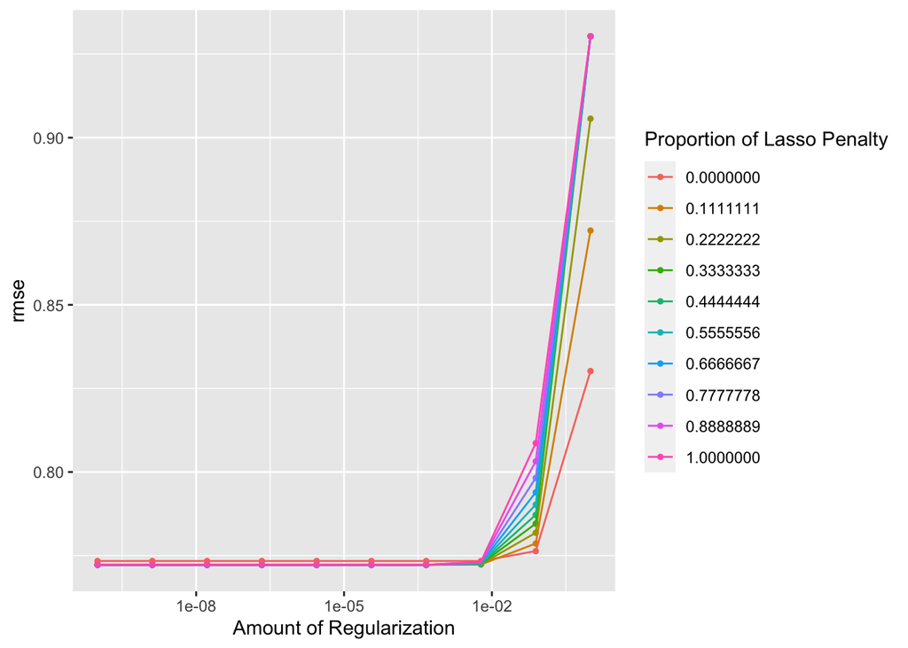

```r
autoplot(en_tune, metric = "rmse")
```

In the elastic net plot, the amount of regularization, on the x-axis, is the penalty hyperparameter and the values of mixture are represented by the different colored lines. We notice that `penalty < 1e-02` results in the lowest RMSE and that `mixture` does not have a significant effect.

### Pruned Decision Trees

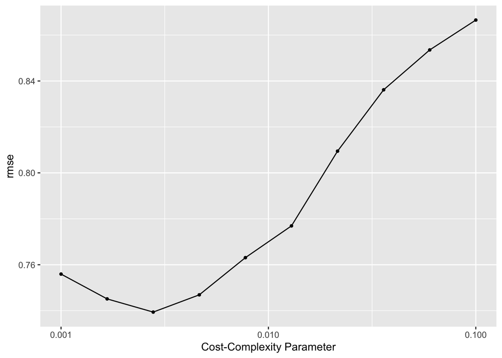

```r
autoplot(pd_tune, metric = "rmse")
```

### Random Forest Autoplot

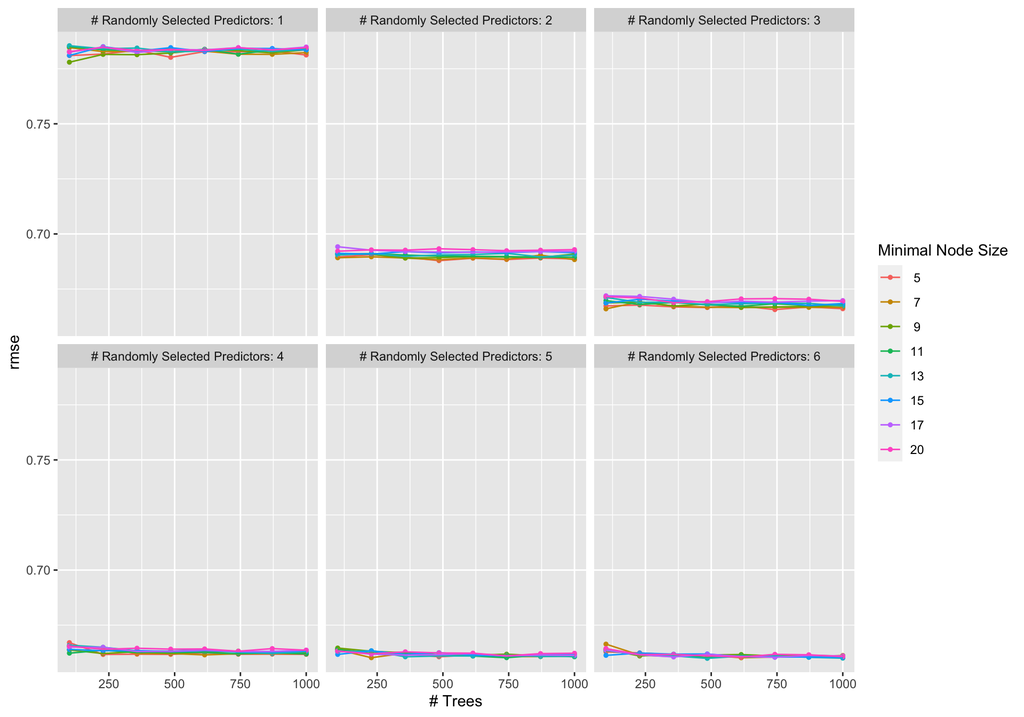

```r
autoplot(rf_tune, metric = "rmse")
```

In the random forest model, we tuned the the number of randomly selected predictor variables considered at each split (`mtry`), the number of trees in the random forest model (`trees`), and the minimal node size, namely, the minimum number of observations required to split a node (`min_n`). From the plot above we see that as `mtry` increases, the RMSE decreases meaning that the model is better. Hyperparameters `trees` and `min_n` do not seem to have a significant impact.

# Best Model

As we observed, random forest performed the best out of our five models with hyperparameters: `mtry = 6`, `trees = 485`, and `min_n = 13`.

## Fitting to Training Data

Let’s fit our best model to the training data.

```r
best_rf <- select_best(rf_tune, metric = "rmse")
final_wf_rf <- finalize_workflow(rf_workflow, best_rf)
final_fit_rf <- fit(final_wf_rf, movie_train)

final_rf_test <- augment(final_fit_rf, new_data = movie_test)
```

## Testing the Model

Now, we’ll test our best model on the testing data.

```r
rmse(final_rf_test, truth = vote_average, estimate = .pred)
```

| .metric | .estimator | .estimate |
| --- | --- | --- |
| rmse | standard | 0.6292969 |

The random forest model with `mtry = 6`, `trees = 485`, and `min_n = 13` produced a testing RMSE of ~0.63 which is lower than the estimated testing RMSE we obtained from cross-validation (which was ~0.66). So, our testing RMSE of 0.63 means that the model’s predictions, on average, deviate by about 0.63 units from the true ratings, which is decent considering that our ratings are on a 0-10 scale!

Take a look at the plot of the predicted values versus the actual values:

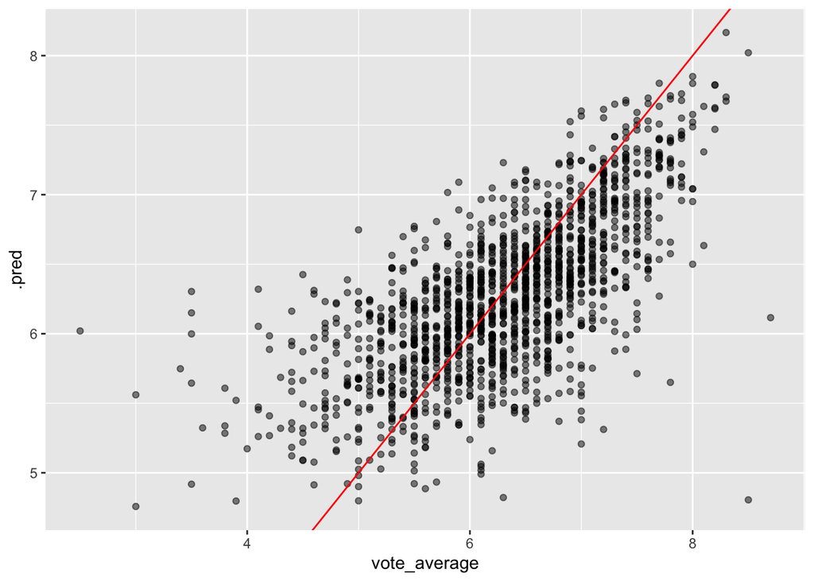

```r
final_rf_test %>%
  ggplot(aes(x = vote_average, y = .pred)) +
  geom_point(alpha = 0.5) +
  #xlim(0,10) +
  #ylim(0,10) +
  geom_abline(col = "red")
```

Ideally, we want the dots to form a straight line, indicating that all of our observations were predicted accurately. Although our observations are not directly on the red line, they are centered around it and follow the same, upwards pattern.

## Variable Importance

Since we specified `importance = "impurity"` in our random forest workflow, we can create and view a variable importance plot, namely, which variables were most important in predicting our outcome variable `vote_average`.

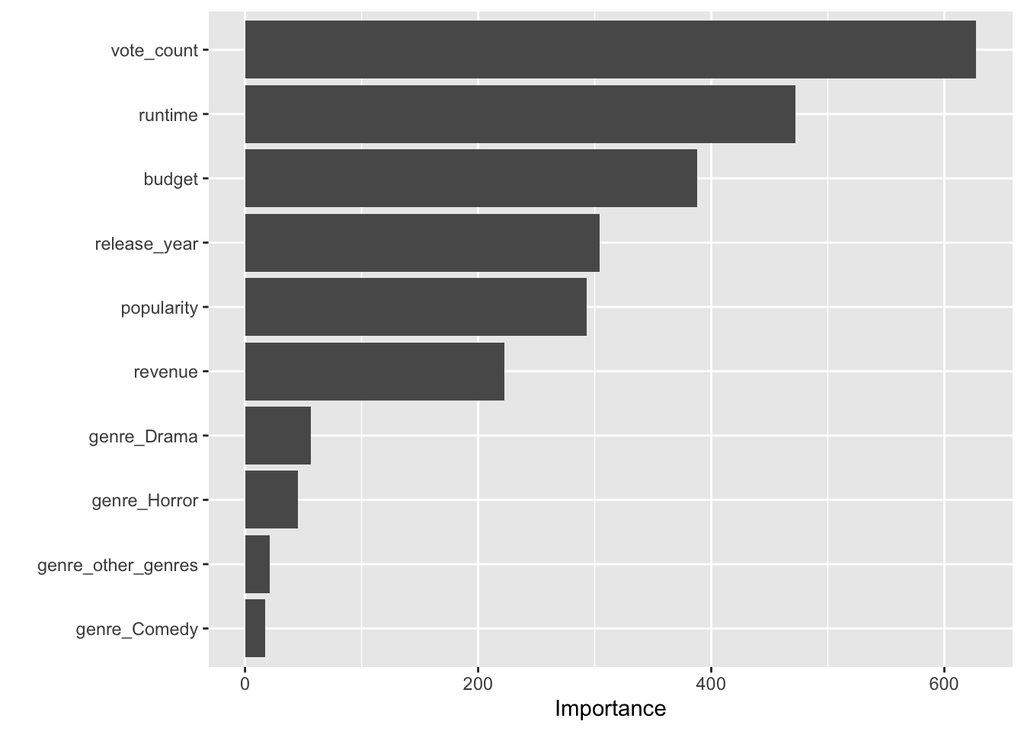

```r
final_fit_rf %>% extract_fit_parsnip() %>%
  vip()
```

From our plot we see that `vote_count` was the most important in predicting `vote_average`. This make sense because more exposure, or a higher number of viewers, provides a more representative sample of the audience’s opinions. Interestingly, `runtime` was the second most important. This indicates that the duration of the movie was the second most impactful variable in predicting the average vote of a movie.

# Conclusion

We have explored a lot of variables that could potentially affect the average vote of a movie and created models to predict this rating. In our EDA, we conducted a visual analysis of our outcome variable `vote_average` and its predictor variables: `budget`, `popularity`, `revenue`, `runtime`, `vote_count`, `genre`, `production_company`, and `release_year`. We observed that the mean of average votes in our dataset was around 6.3 on a 0-10 scale. Another interesting observation we found was that `vote_count` and `revenue` had a strong, positive correlation as well as `revenue` and `budget`.

We created and analyzed five models: (1) linear regression, (2) *k*-nearest neighbors, (3) elastic net, (4) pruned decision trees, and (5) random forest. Random forest performed the best with hyperparameters `mtry = 6`, `trees = 485`, and `min_n = 13` and predicted the average movie rating fairly well based on the RMSE. This is not very surprising because random forest models are less prone to overfitting compared to other models, can handle non-linearity, and are overall more flexible.

The model that performed the worst was elastic net. Elastic net models, being a combination of lasso and ridge regression, introduce additional complexities compared to other models like linear regression or random forests which can lead to overfitting. Elastic net also penalizes the coefficients of correlated features, which can be problematic if the dataset contains multicollinearity, which in this case it does because we identified two highly correlated sets of variables in our correlation plot.

One lingering question I have is: what would have happened if we imputed all the missing data rather than omitting it? Would it have improved our model because we would’ve had more observations or was there just too much to impute that it would not be feasible? The proportion of missing data to the total size of the dataset seemed too large to impute, which is why I just omitted it, but losing so much data that could have been valuable leads me to wonder if there was a better way to handle this.

If I were to continue this project I would add more predictor variables. We only used one dataset from the larger dataset itself. If we were to merge this dataset with the ratings dataset, which contains individual user ratings for a large handful of movies, we could expand this project into a more personalized recommendation system. There is another dataset called credits.csv with cast and crew information. Merging this with our current dataset could potentially contain valuable information that improves our prediction and could have a significant effect on average movie rating. Perhaps A-list actors or illustrious directors could positively influence the average rating of a movie.

In conclusion, this project has been a fulfilling experience, merging my interest in movies with the practical application of machine learning. Exploring real-world datasets and implementing various models has equipped me with valuable skills for future data-driven projects and has greatly contributed to my growth as a data scientist. I am proud to have developed a model that predicts the average rating of a movie fairly well!

# Sources

Banik, R. (2017, November 10). The Movies Dataset. Kaggle. https://www.kaggle.com/datasets/rounakbanik/the-movies-dataset